# Ejemplo de aplicacion de SHAP a XGBOOST

Santiago Andres Sotelo

6 de Diciembre de 2021

Limpio la memoria y borro objetos

```r
rm( list=ls() )
gc()
```

```
          used  (Mb) gc trigger  (Mb) max used  (Mb)
Ncells 2670379 142.7    4920091 262.8  3761055 200.9
Vcells 5050327  38.6   10146329  77.5  7694599  58.8
```

# Carga de librerias, importacion de dataset y definicion objetivo

Volvemos a cargar el Dataset de **Boston** y definimos cuales son los features que vamos a utilizar para predecir. EN este caso vamos a elegir nuevamente las mismas variables que en **Ejemplo 1**. A continuacion vamos a hacer un recorte del dataset total y nos vamos a quedar con 6 observaciones para trabajar y que no crezca demasiado la complejidad computacional.

```r
library(xgboost)
library(shapr)

data("Boston", package = "MASS")

x_var <- c("nox", "rm", "dis", "age")
y_var <- "medv"

x_train <- as.matrix(Boston[-1:-6, x_var])
y_train <- Boston[-1:-6, y_var]
x_test <- as.matrix(Boston[1:6, x_var])
```

Se setea la data para explicar

```r
explainer <- shapr(x_train, model)
```

```
The specified model provides feature classes that are NA. The classes of data are taken as the truth.
```

Se calcula el fi_0 es decir la prediccion sin features

```r
p <- mean(y_train)
```

#Calculo de los Shapley Values

Se calculan los valores SHAP utilizando el kernelSHAP tomando en cuenta para la dependencia de features el uso de la distrbucion empirica (condicional) con un parametro sigma para el ancho de banda de 0.1 que es el valor por default

```r
explanation <- explain(
  x_test,
  approach = "empirical",
  explainer = explainer,
  prediction_zero = p
)
```

# Visualizacion de la importancia de los Feautres

Vemos para la cantidad seleccionada de features cual es la importancia,es decir que tanto agregan o no a la explicabilidad del modelo general.

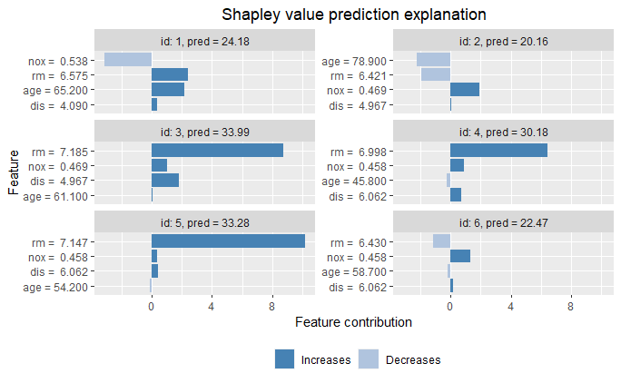

```r
plot(explanation, plot_phi0 = FALSE, index_x_test = c(1,2,3,4,5,6))
```

```r
NA
NA
```

# Analisis de los Valores Globales

Luego observamos cuales fueron los valores individuales de Shap para cada feature para cada observacion

```r
explicaciones.df <- as.data.frame(explanation$dt[,2:5])
explicaciones.df
```

| nox | rm | dis | age |
| --- | --- | --- | --- |
| -3.1707575 | 2.419759 | 0.33913069 | 2.14139694 |
| 1.9302018 | -1.984861 | 0.03672265 | -2.27297916 |
| 1.0059975 | 8.755733 | 1.77234641 | 0.01154156 |
| 0.8516017 | 6.438233 | 0.71769109 | -0.27610470 |
| 0.3404609 | 10.214643 | 0.41263011 | -0.13083621 |
| 1.3130801 | -1.195127 | 0.14958148 | -0.23955904 |

```r
NA
```

Y finalmente observamos cual es el valor SHAP Global de cada feature promediando sus valores

```r
global=as.data.frame(apply(explicaciones.df[,1:4],2,mean))

colnames(global)=c("Shapleys Globales")

global
```

|  | Shapleys Globales |
| --- | --- |
| nox | 0.3784307 |
| rm | 4.1080636 |
| dis | 0.5713504 |
| age | -0.1277568 |

```r
NA
```